# Molecular Subtype Prediction of Brain Lower-Grade Gliomas

Grace

2026-04-09

# Phase 1: Environment Setup and Data Loading

In this phase, we load the integrated dataset containing both the LGG molecular subtypes and high-throughput mRNA expression values. We also initialize the core libraries required for data manipulation, visualization, and machine learning.

```r
# Define data path and load dataset
file_path <- "../data/LGG-mrna-expression-data-with-cancer-subtypes.csv"
lgg_data <- read.csv(file_path)

# Preview the first 10 rows
head(lgg_data, 10)
```

```
##     PATIENT_ID       SAMPLE_ID              SUBTYPE UBE2Q2P2 HMGB1P1 RNU12.2P
## 1 TCGA-CS-4938 TCGA-CS-4938-01 LGG_IDHmut-non-codel  22.7523 268.576   0.4196
## 2 TCGA-CS-4941 TCGA-CS-4941-01            LGG_IDHwt  21.1767 156.687   1.7253
## 3 TCGA-CS-4942 TCGA-CS-4942-01 LGG_IDHmut-non-codel  11.0242 185.138   0.0000
## 4 TCGA-CS-4943 TCGA-CS-4943-01 LGG_IDHmut-non-codel   5.0835 269.836   0.3261
## 5 TCGA-CS-4944 TCGA-CS-4944-01 LGG_IDHmut-non-codel  30.2610 216.341   0.0000
##    EZHIP EFCAB8 SRP14P1 TRIM75P  HSPB1P1 ANKRD20A20P  GTPBP6  EFCAB12    A1BG
## 1 2.0978 0.4196 12.5865  0.0000  58.3176      2.0978 572.268  33.5641 94.1095
## 2 3.4507 0.3451 15.1829  0.3451 120.7730      1.3803 734.299 108.3510 72.2326
## 3 1.7301 0.3460 14.8789  0.0000  38.7543      0.3460 674.740  13.1488 74.4533
## 4 1.3043 0.0000 10.4344  0.3261  24.4556      4.5650 777.035   4.2390 29.9858
## 5 3.0261 0.0000 23.2001  0.0000 166.9400      0.0000 830.664  14.1218 24.7132
##      A2BP1    A2LD1     A2M   A2ML1   A4GALT  A4GNT AAA1     AAAS    AACS AACSL
## 1  22.6558  13.4844 14783.7 146.004  73.4214 0.0000    0  584.854 247.116     0
## 2 524.5000 144.0860 17944.7 521.394 159.7650 1.0352    0  359.903 297.447     0
```

[output cut: 12580 more lines]

```r
# Load required libraries
library(dplyr)
library(ggplot2)
library(patchwork)
library(caret)
library(nnet)
```

# Phase 2: Exploratory Data Analysis (EDA)

Here, we explore the distribution of the cancer subtypes and examine the expression profile of a specific gene of interest, *ERBB2* (HER2), across different molecular groups.

## Subtype Specific Summary Statistics

```r
# Calculate summary statistics for ERBB2 expression grouped by subtype
erbb2_summary <- lgg_data %>%
  group_by(SUBTYPE) %>%
  summarise(
    n = n(),
    mean_expression = mean(ERBB2, na.rm = TRUE),
    median_expression = median(ERBB2, na.rm = TRUE),
    sd_expression = sd(ERBB2, na.rm = TRUE),
    min_expression = min(ERBB2, na.rm = TRUE),
    max_expression = max(ERBB2, na.rm = TRUE)
  )

erbb2_summary
```

```
## # A tibble: 3 × 7
##   SUBTYPE       n mean_expression median_expression sd_expression min_expression
##   <chr>     <int>           <dbl>             <dbl>         <dbl>          <dbl>
## 1 LGG_IDHm…   167            699.              670.          188.           330.
## 2 LGG_IDHm…   248            597.              585.          158.           217.
## 3 LGG_IDHwt    92           1586.             1495.         1055.           127.
## # ℹ 1 more variable: max_expression <dbl>
```

## Visualizing Subtype Frequencies

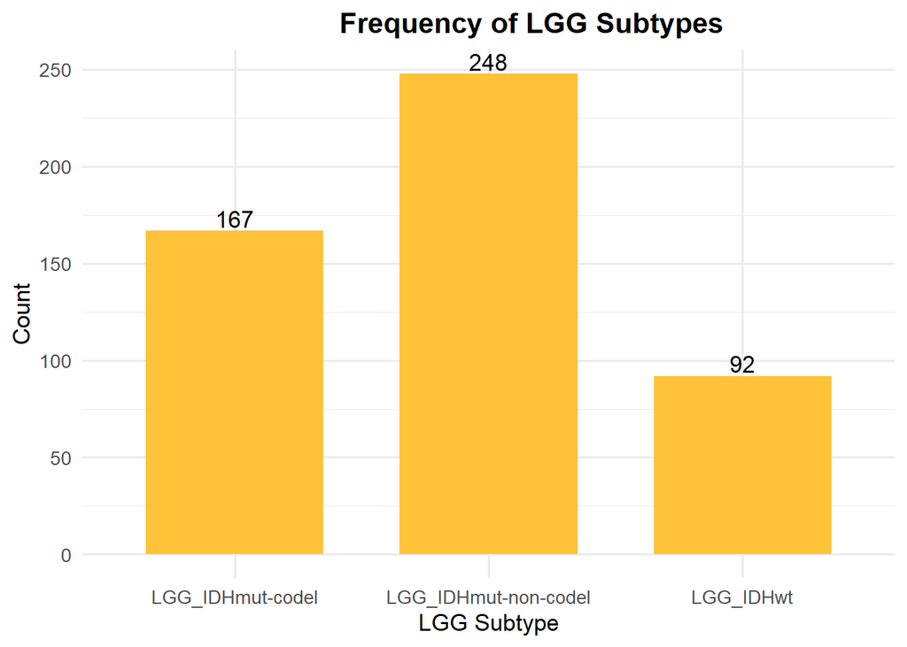

```r
# Bar plot to visualize the frequency of each LGG subtype
ggplot(lgg_data, aes(x = SUBTYPE)) +
  geom_bar(fill = "#ffc238", width = 0.7) +
  geom_text(
    stat = "count",
    aes(label = after_stat(count)),
    vjust = -0.2
  ) +
  labs(
    title = "Frequency of LGG Subtypes",
    x = "LGG Subtype",
    y = "Count"
  ) +
  theme_minimal(base_size = 13) +
  theme(
    plot.title = element_text(hjust = 0.6, face = "bold")
  )
```

## Visualizing ERBB2 Expression Distribution

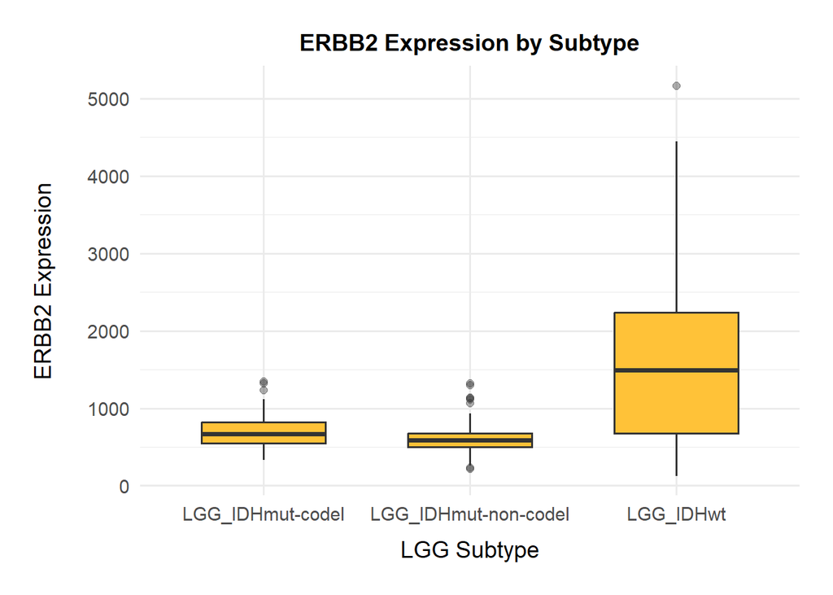

```r
# Boxplot for ERBB2 expression by subtype
ggplot(lgg_data, aes(x = SUBTYPE, y = ERBB2)) +
  geom_boxplot(fill = "#ffc238", width = 0.6, outlier.alpha = 0.4) +
  labs(
    title = "ERBB2 Expression by Subtype",
    x = "LGG Subtype",
    y = "ERBB2 Expression"
  ) +
  theme_minimal(base_size = 14) +
  theme(
    plot.title = element_text(hjust = 0.5, face = "bold", size = 14),
    axis.title.x = element_text(margin = margin(t = 10)),
    axis.title.y = element_text(margin = margin(r = 20)),
    axis.text.x = element_text(hjust = 0.5),
    plot.margin = margin(20, 20, 20, 20)
  )
```

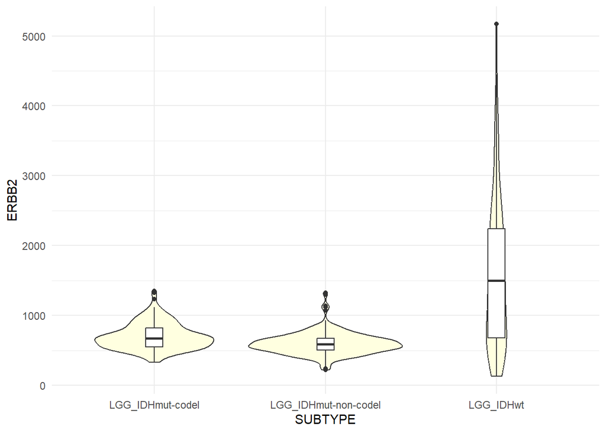

```r
# Violin plot overlaid with boxplot for ERBB2 distribution
ggplot(lgg_data, aes(x = SUBTYPE, y = ERBB2)) +
  geom_violin(fill = "lightyellow") +
  geom_boxplot(width = 0.1, fill = "white") +
  theme_minimal()
```

## Statistical Testing: One-way ANOVA

```r
# Perform One-way ANOVA to test if ERBB2 expression differs across subtypes
anova_result <- aov(ERBB2 ~ SUBTYPE, data = lgg_data)

# Display the ANOVA table to check for statistical significance
summary(anova_result)
```

```
##              Df    Sum Sq  Mean Sq F value Pr(>F)
## SUBTYPE       2  68623247 34311624   152.6 <2e-16 ***
## Residuals   504 113320688   224843
## ---
## Signif. codes:  0 '***' 0.001 '**' 0.01 '*' 0.05 '.' 0.1 ' ' 1
```

```r
# Interpretation: There is a statistically significant difference in ERBB2 expression levels between at least two of the LGG tumor subtypes.
```

# Phase 3: Data Transformation and Feature Selection

High-throughput transcriptomic data often exhibit strong right-skewness and heteroscedasticity. Here, we evaluate different log transformations and filter out low-variance genes to optimize the feature space for modeling.

## Evaluating Log Transformations

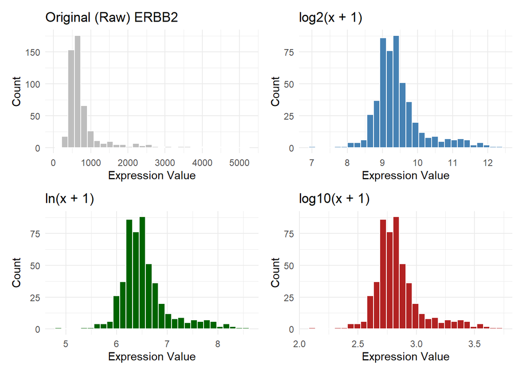

```r
# Visualizing the raw vs. transformed expression values
lgg_comparison <- lgg_data %>%
  mutate(
    raw = ERBB2,
    log2_trans = log2(ERBB2 + 1),
    ln_trans = log(ERBB2 + 1),
    log10_trans = log10(ERBB2 + 1)
  )

# Define a function to plot histograms
plot_hist <- function(data, col, title, color) {
  ggplot(data, aes(x = .data[[col]])) +
    geom_histogram(bins = 30, fill = color, color = "white") +
    labs(title = title, x = "Expression Value", y = "Count") +
    theme_minimal()
}

p1 <- plot_hist(lgg_comparison, "raw", "Original (Raw) ERBB2", "gray")
p2 <- plot_hist(lgg_comparison, "log2_trans", "log2(x + 1)", "steelblue")
p3 <- plot_hist(lgg_comparison, "ln_trans", "ln(x + 1)", "darkgreen")
p4 <- plot_hist(lgg_comparison, "log10_trans", "log10(x + 1)", "firebrick")

# Combine plots using patchwork
(p1 | p2) / (p3 | p4)
```

## Applying Log2 Transformation Globally

```r
# Identify all gene expression columns (excluding SUBTYPE)
gene_cols <- sapply(lgg_data, is.numeric)
gene_cols["SUBTYPE"] <- FALSE

# Apply log2(x + 1) transformation to stabilize variance
lgg_data_log2 <- lgg_data
lgg_data_log2[gene_cols] <- log2(lgg_data_log2[gene_cols] + 1)

head(lgg_data_log2, 10)
```

```
##     PATIENT_ID       SAMPLE_ID              SUBTYPE UBE2Q2P2  HMGB1P1  RNU12.2P
## 1 TCGA-CS-4938 TCGA-CS-4938-01 LGG_IDHmut-non-codel 4.569995 8.074548 0.5054845
## 2 TCGA-CS-4941 TCGA-CS-4941-01            LGG_IDHwt 4.470973 7.300920 1.4464150
## 3 TCGA-CS-4942 TCGA-CS-4942-01 LGG_IDHmut-non-codel 3.587869 7.540229 0.0000000
## 4 TCGA-CS-4943 TCGA-CS-4943-01 LGG_IDHmut-non-codel 2.604902 8.081276 0.4071896
## 5 TCGA-CS-4944 TCGA-CS-4944-01 LGG_IDHmut-non-codel 4.966292 7.763817 0.0000000
##      EZHIP    EFCAB8  SRP14P1   TRIM75P  HSPB1P1 ANKRD20A20P   GTPBP6  EFCAB12
## 1 1.631244 0.5054845 3.764102 0.0000000 5.890388   1.6312440 9.163066 5.111202
## 2 2.154032 0.4277134 4.016398 0.4277134 6.928050   1.2511434 9.522187 6.772823
## 3 1.448954 0.4286784 3.989039 0.0000000 5.313039   0.4286784 9.400324 3.822608
## 4 1.204329 0.0000000 3.515309 0.4071896 4.669911   2.4763817 9.603691 2.389291
## 5 2.009383 0.0000000 4.596941 0.0000000 7.391802   0.0000000 9.699857 3.918558
##       A1BG    A2BP1    A2LD1      A2M    A2ML1   A4GALT     A4GNT AAA1
## 1 6.571518 4.564122 3.856428 13.85182 7.199712 6.217646 0.0000000    0
## 2 6.194414 9.037547 7.180765 14.13135 9.028995 7.328810 1.0251706    0
```

[output cut: 14032 more lines]

## High-Variance Feature Selection

```r
# Identify numeric gene columns in the log-transformed data
gene_names <- colnames(lgg_data_log2)[sapply(lgg_data_log2, is.numeric)]

# Calculate variance per gene on the log scale
gene_vars <- apply(lgg_data_log2[, gene_names], 2, var)

# Filter out the bottom 20% lowest variance genes
threshold <- quantile(gene_vars, 0.2)
high_var_genes <- names(gene_vars[gene_vars > threshold])

# Create filtered dataset
lgg_data_filtered <- lgg_data_log2[, c("SUBTYPE", high_var_genes)]

genes_dropped <- length(gene_names) - length(high_var_genes)
genes_remaining <- length(high_var_genes)

cat("Summary of Variance Filtering:\n")
```

```
## Summary of Variance Filtering:
```

```r
cat("- Number of genes dropped (low variance):", genes_dropped, "\n")
```

```
## - Number of genes dropped (low variance): 3728
```

```r
cat("- Number of genes remaining (high variance):", genes_remaining, "\n")
```

```
## - Number of genes remaining (high variance): 14912
```

### Analysis of Dropped Genes

```r
# Extract full data for all dropped genes
dropped_gene_names <- names(gene_vars[gene_vars <= threshold])
lgg_data_dropped_full <- lgg_data_log2[, c("SUBTYPE", dropped_gene_names)]

# Create a summary table of the dropped genes and their variances
dropped_summary <- data.frame(
  Gene = dropped_gene_names,
  Variance = gene_vars[dropped_gene_names]
)

cat("\n--- Top 10 Genes with the Lowest Variance (Most Stable) ---\n")
```

```
##
## --- Top 10 Genes with the Lowest Variance (Most Stable) ---
```

```r
top_10_low_var <- dropped_summary[order(dropped_summary$Variance), ]
print(head(top_10_low_var, 10))
```

```
##            Gene   Variance
## CIAO1     CIAO1 0.02817540
## TRPC4AP TRPC4AP 0.03411640
## GGNBP2   GGNBP2 0.03811291
## GPBP1     GPBP1 0.04228166
## KCMF1     KCMF1 0.04255488
## PI4KB     PI4KB 0.04319346
## ZDHHC7   ZDHHC7 0.04375359
## UBE2D2   UBE2D2 0.04465270
## UBE2V1   UBE2V1 0.04487054
## PCBP1     PCBP1 0.04515689
```

```r
# Calculate and show the Variance Range of all dropped genes
var_range <- range(dropped_summary$Variance)
cat("\n--- Variance Range of All Dropped Genes ---\n")
```

```
##
## --- Variance Range of All Dropped Genes ---
```

```r
cat("Minimum Variance:", var_range[1], "\n")
```

```
## Minimum Variance: 0.0281754
```

```r
cat("Maximum Variance (at 20% threshold):", var_range[2], "\n")
```

```
## Maximum Variance (at 20% threshold): 0.1744221
```

## Z-Score Standardization

```r
# Standardize only the remaining high-variance genes to ensure equal feature weight
num_cols_final <- sapply(lgg_data_filtered, is.numeric)
lgg_data_std <- lgg_data_filtered
lgg_data_std[, num_cols_final] <- scale(lgg_data_std[, num_cols_final])

# Save preprocessed and filtered data for future use
write.csv(lgg_data_filtered, "../data/lgg_mrna_preprocessed_highvar.csv", row.names = FALSE)
cat("Preprocessed data saved to lgg_mrna_preprocessed_highvar.csv\n")
```

```
## Preprocessed data saved to lgg_mrna_preprocessed_highvar.csv
```

# Phase 4: Model Preparation - Data Splitting

We split our standardized data into independent training and testing sets to prevent data leakage and evaluate our model’s generalizability fairly.

```r
set.seed(2026)

# Calculate the number of training samples (80%)
train_idx <- sample(1:nrow(lgg_data_std), 0.8 * nrow(lgg_data_std))

# Create training and testing datasets
train_data <- lgg_data_std[train_idx, ]
test_data  <- lgg_data_std[-train_idx, ]

cat("Training set size:", nrow(train_data), "\n")
```

```
## Training set size: 405
```

```r
cat("Testing set size:", nrow(test_data), "\n")
```

```
## Testing set size: 102
```

# Phase 5: Dimensionality Reduction via PCA

To combat the “curse of dimensionality” from thousands of genes, we apply Principal Component Analysis (PCA) to condense data variance into key components.

## Running PCA

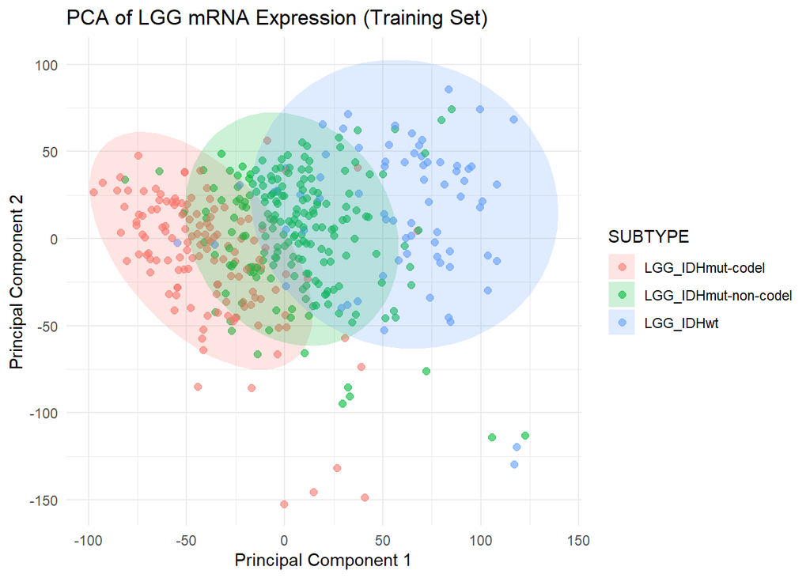

```r
# Run PCA on numeric columns of the training data
pca_res <- prcomp(train_data[, -1], center = FALSE, scale. = FALSE)

# Extract PC scores for plotting
pca_df <- as.data.frame(pca_res$x)
pca_df$SUBTYPE <- train_data$SUBTYPE

# Plot PC1 vs PC2
ggplot(pca_df, aes(x = PC1, y = PC2, color = SUBTYPE, fill = SUBTYPE)) +
  geom_point(alpha = 0.6, size = 2) +
  stat_ellipse(level = 0.95, geom = "polygon", alpha = 0.2, color = NA) +
  theme_minimal() +
  labs(title = "PCA of LGG mRNA Expression (Training Set)",
       x = "Principal Component 1",
       y = "Principal Component 2")
```

## Scree Plot Analysis

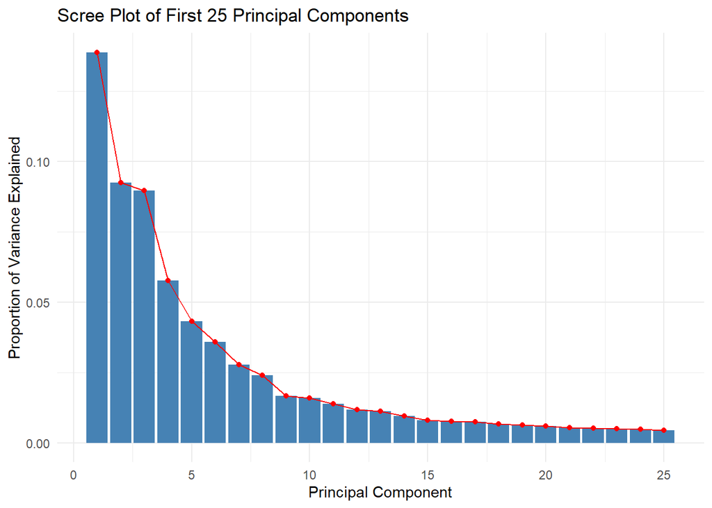

```r
# Calculate variance explained by each principal component
prop_var <- (pca_res$sdev^2) / sum(pca_res$sdev^2)

# Create a data frame for the first 25 PCs
scree_df <- data.frame(PC = 1:25, Variance = prop_var[1:25])

# Plot the Scree Plot
ggplot(scree_df, aes(x = PC, y = Variance)) +
  geom_bar(stat = "identity", fill = "steelblue") +
  geom_line(group = 1, color = "red") +
  geom_point(color = "red") +
  theme_minimal() +
  labs(title = "Scree Plot of First 25 Principal Components",
       x = "Principal Component", y = "Proportion of Variance Explained")
```

```r
cum_var_25 <- sum(prop_var[1:25])
cat("Total variance explained by the first 25 PCs:", round(cum_var_25 * 100, 2), "%\n")
```

```
## Total variance explained by the first 25 PCs: 65.46 %
```

# Phase 6: Addressing Class Imbalance & Model Training

We project test data onto the training PCA space, address the class imbalance via up-sampling based on the “One in Ten Rule”, and train our primary 7-PC Multinomial Logistic Regression model.

## Projecting Test Data

```r
# Project Test Data onto Training PCA Space
test_pca_scores <- predict(pca_res, newdata = test_data[, -1])
pca_test_tibble <- tibble::as_tibble(test_pca_scores)
```

## Class Distribution and Up-sampling

```r
train_counts <- table(train_data$SUBTYPE)
cat("--- Original Training Counts ---\n")
```

```
## --- Original Training Counts ---
```

```r
print(train_counts)
```

```
##
##     LGG_IDHmut-codel LGG_IDHmut-non-codel            LGG_IDHwt
##                  135                  197                   73
```

```r
# Apply 'One in Ten Rule': Smallest class has 73 samples. 73 / 10 = 7.3 features allowed.
X_features <- 7
pc_names <- paste0("PC", 1:X_features)

# Integrate SUBTYPE labels with PCA scores
train_pca_data <- cbind(SUBTYPE = train_data$SUBTYPE, as.data.frame(pca_res$x[, 1:X_features]))

# Perform up-sampling to balance the classes
set.seed(2026)
train_balanced <- upSample(x = train_pca_data[, pc_names],
                           y = as.factor(train_pca_data$SUBTYPE),
                           yname = "SUBTYPE")

cat("\n--- Balanced Training Counts (Up-sampled) ---\n")
```

```
##
## --- Balanced Training Counts (Up-sampled) ---
```

```r
print(table(train_balanced$SUBTYPE))
```

```
##
##     LGG_IDHmut-codel LGG_IDHmut-non-codel            LGG_IDHwt
##                  197                  197                  197
```

## Fitting the 7-PC Model

```r
# Set 'LGG_IDHwt' as the clinical reference level (most aggressive subtype)
train_balanced$SUBTYPE <- as.factor(train_balanced$SUBTYPE)
train_balanced$SUBTYPE <- relevel(train_balanced$SUBTYPE, ref = "LGG_IDHwt")

model_formula <- as.formula(paste("SUBTYPE ~", paste(pc_names, collapse = " + ")))

# Fit model
model_lgg <- multinom(model_formula, data = train_balanced, trace = FALSE)

cat("\n--- Multinomial Model Summary ---\n")
```

```
##
## --- Multinomial Model Summary ---
```

```r
summary(model_lgg)
```

```
## Call:
## multinom(formula = model_formula, data = train_balanced, trace = FALSE)
##
## Coefficients:
##                      (Intercept)         PC1         PC2        PC3         PC4
## LGG_IDHmut-codel      -0.8660547 -0.12837799 -0.04546807 0.02012520 -0.02605851
## LGG_IDHmut-non-codel   2.6818359 -0.05525061 -0.03131976 0.09920972 -0.20953363
##                             PC5         PC6         PC7
## LGG_IDHmut-codel      0.1079751 -0.02598066 -0.07106614
## LGG_IDHmut-non-codel -0.0909236  0.18315975 -0.09178412
##
## Std. Errors:
##                      (Intercept)        PC1        PC2        PC3        PC4
## LGG_IDHmut-codel       1.9005088 0.02765698 0.01509762 0.02819204 0.04876800
## LGG_IDHmut-non-codel   0.9543336 0.01851892 0.01141522 0.02151747 0.05069631
##                             PC5        PC6        PC7
## LGG_IDHmut-codel     0.04119431 0.05492760 0.03790862
## LGG_IDHmut-non-codel 0.02925107 0.04827349 0.02690914
##
## Residual Deviance: 98.92731
## AIC: 130.9273
```

## Evaluating the 7-PC Model

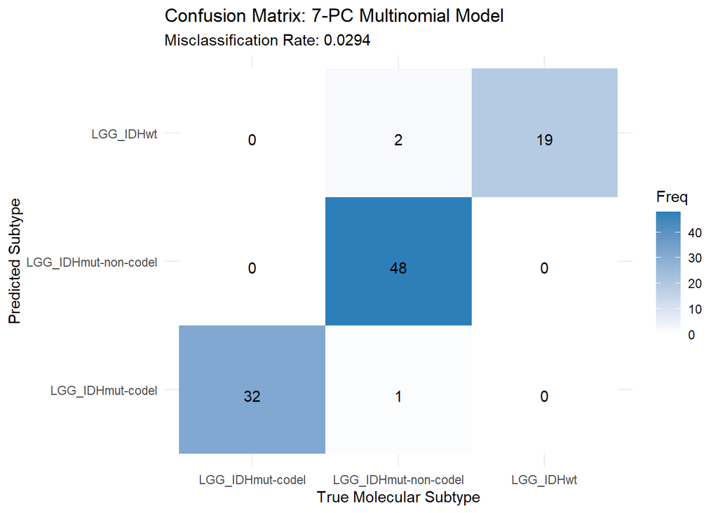

```r
actual_labels <- as.factor(test_data$SUBTYPE)

test_pred_7 <- predict(model_lgg, newdata = pca_test_tibble)
test_pred_7 <- factor(test_pred_7, levels = levels(actual_labels))

conf_matrix_7 <- table(Predicted = test_pred_7, Actual = actual_labels)
accuracy <- sum(diag(conf_matrix_7)) / sum(conf_matrix_7)
miss_rate_7 <- 1 - accuracy

# Plot Confusion Matrix Heatmap
df_cm <- as.data.frame(conf_matrix_7)
ggplot(df_cm, aes(x = Actual, y = Predicted, fill = Freq)) +
  geom_tile() +
  geom_text(aes(label = Freq), vjust = 1) +
  scale_fill_gradient(low = "white", high = "#2c7fb8") +
  theme_minimal() +
  labs(title = "Confusion Matrix: 7-PC Multinomial Model",
       subtitle = paste("Misclassification Rate:", round(miss_rate_7, 4)),
       x = "True Molecular Subtype",
       y = "Predicted Subtype")
```

# Phase 7: Model Comparison (2-PC & 100-PC Models)

## Training and Validating 2-PC Model

```r
X2 <- 2
pc_names_2 <- paste0("PC", 1:X2)

formula_2 <- as.formula(paste("SUBTYPE ~", paste(pc_names_2, collapse = " + ")))
model_2pc <- multinom(formula_2, data = train_balanced, trace = FALSE)

test_pc_2 <- as.data.frame(predict(pca_res, newdata = test_data[, -1])[, 1:X2])
pred_2pc <- predict(model_2pc, newdata = test_pc_2)
pred_2pc <- factor(pred_2pc, levels = levels(as.factor(test_data$SUBTYPE)))

conf_matrix_2 <- table(Predicted = pred_2pc, Actual = test_data$SUBTYPE)
miss_rate_2 <- 1 - sum(diag(conf_matrix_2)) / sum(conf_matrix_2)

cat("Misclassification Rate (2 PCs):", round(miss_rate_2, 4), "\n")
```

```
## Misclassification Rate (2 PCs): 0.2157
```

### Visualizing 2-PC Decision Boundaries

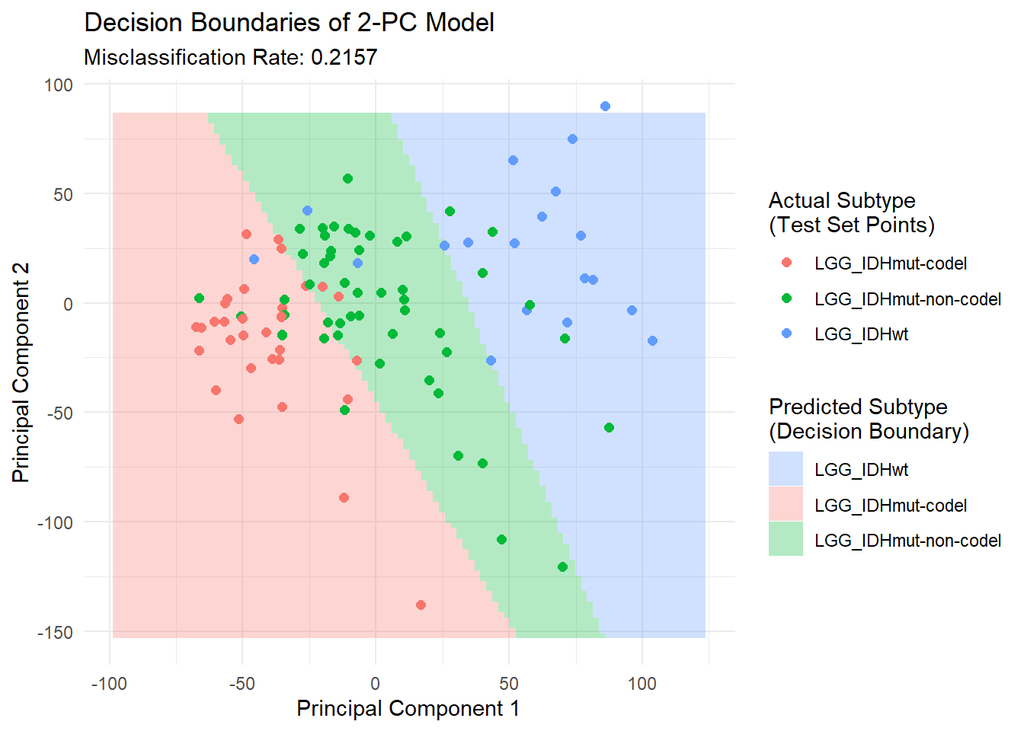

```r
# Define uniform color mapping for consistency
my_colors <- c(
  "LGG_IDHmut-codel" = "#F8766D",
  "LGG_IDHmut-non-codel" = "#00BA38",
  "LGG_IDHwt" = "#619CFF"
)

# Create prediction grid for decision boundaries
grid <- expand.grid(
  PC1 = seq(min(pca_df$PC1), max(pca_df$PC1), length.out = 100),
  PC2 = seq(min(pca_df$PC2), max(pca_df$PC2), length.out = 100)
)
grid$SUBTYPE <- predict(model_2pc, newdata = grid)

test_points <- as.data.frame(cbind(test_pc_2, SUBTYPE = test_data$SUBTYPE))

ggplot() +
  geom_tile(data = grid, aes(x = PC1, y = PC2, fill = SUBTYPE), alpha = 0.3) +
  scale_fill_manual(values = my_colors) +
  geom_point(data = test_points, aes(x = PC1, y = PC2, color = SUBTYPE), size = 2) +
  scale_color_manual(values = my_colors) +
  theme_minimal() +
  guides(
    fill = guide_legend(title = "Predicted Subtype\n(Decision Boundary)"),
    color = guide_legend(title = "Actual Subtype\n(Test Set Points)")
  ) +
  labs(title = "Decision Boundaries of 2-PC Model",
       subtitle = paste("Misclassification Rate:", round(miss_rate_2, 4)),
       x = "Principal Component 1",
       y = "Principal Component 2")
```

## Training and Validating 100-PC Model

```r
X100 <- 100
pc_names_100 <- paste0("PC", 1:X100)
train_pca_100 <- cbind(SUBTYPE = train_data$SUBTYPE, as.data.frame(pca_res$x[, 1:X100]))

# Re-balance for 100 features
set.seed(2026)
train_bal_100 <- upSample(x = train_pca_100[, pc_names_100],
                          y = as.factor(train_pca_100$SUBTYPE),
                          yname = "SUBTYPE")

formula_100 <- as.formula(paste("SUBTYPE ~", paste(pc_names_100, collapse = " + ")))
model_100pc <- multinom(formula_100, data = train_bal_100, trace = FALSE)

test_pc_100 <- as.data.frame(predict(pca_res, newdata = test_data[, -1])[, 1:X100])
pred_100pc <- predict(model_100pc, newdata = test_pc_100)
pred_100pc <- factor(pred_100pc, levels = levels(as.factor(test_data$SUBTYPE)))

conf_matrix_100 <- table(Predicted = pred_100pc, Actual = test_data$SUBTYPE)
miss_rate_100 <- 1 - sum(diag(conf_matrix_100)) / sum(conf_matrix_100)

cat("Misclassification Rate (100 PCs):", round(miss_rate_100, 4), "\n")
```

```
## Misclassification Rate (100 PCs): 0.0196
```

# Phase 8: Final Model Evaluation and Comparison

Finally, we aggregate the performance across the three tested models to evaluate the effectiveness of dimensionality reduction under the “One in Ten” rule.

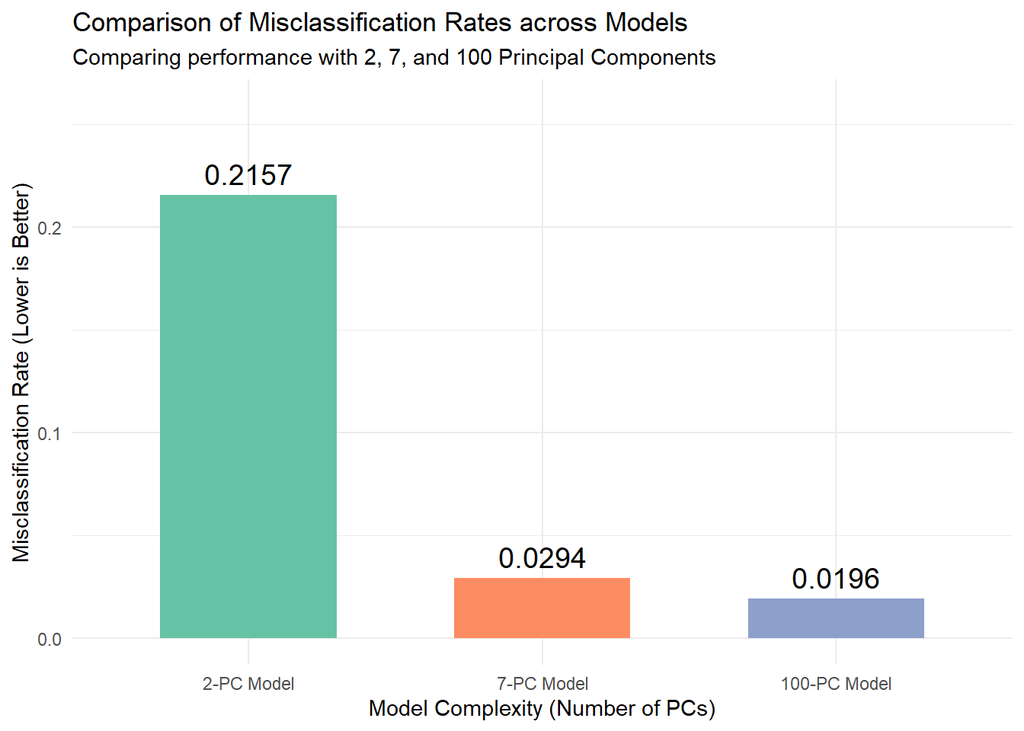

```r
performance_df <- data.frame(
  Num_PCs = c(2, 7, 100),
  Model_Name = c("2-PC Model", "7-PC Model", "100-PC Model"),
  Misclassification_Rate = c(miss_rate_2, miss_rate_7, miss_rate_100)
)

performance_df$Model_Name <- factor(performance_df$Model_Name,
                                    levels = c("2-PC Model", "7-PC Model", "100-PC Model"))

# Plot performance comparison
ggplot(performance_df, aes(x = Model_Name, y = Misclassification_Rate, fill = Model_Name)) +
  geom_bar(stat = "identity", width = 0.6, show.legend = FALSE) +
  geom_text(aes(label = round(Misclassification_Rate, 4)), vjust = -0.5, size = 5) +
  scale_fill_brewer(palette = "Set2") +
  theme_minimal() +
  labs(title = "Comparison of Misclassification Rates across Models",
       subtitle = "Comparing performance with 2, 7, and 100 Principal Components",
       x = "Model Complexity (Number of PCs)",
       y = "Misclassification Rate (Lower is Better)") +
  ylim(0, max(performance_df$Misclassification_Rate) * 1.2)
```